# Tidybiology Final: PKA activity

2023-11-06

## Load libraries

I loaded the tidyverse and wes_palette (for colors).

```r
# install.packages("wesanderson")
library(wesanderson)
library(tidyverse)
```

## Import dataset

I used microscope data that I had collected from cells under four different conditions. This yielded a table of 6 columns and 840 rows. I changed all my column types to numeric. There were many blank spaces with empty cells, so I just filled those in with *** and set my NA = *** when importing. I also had a much longer excel file name, so I just renamed it to PKA_df when importing.

```r
knitr::opts_chunk$set(echo = TRUE)
library(readxl)
library(readxl)
PKA_df <- read_excel("PKA activity longform.xlsx",
    col_types = c("numeric", "numeric", "numeric",
        "numeric", "numeric", "numeric"),
    na = "***")
glimpse(PKA_df)
```

```
## Rows: 840
## Columns: 6
## $ Replicate    <dbl> 1, 1, 1, 1, 1, 1, 1, 1, 1, 1, 1, 1, 1, 1, 1, 1, 1, 1, 1, …
## $ Time         <dbl> 0.5, 1.0, 1.5, 2.0, 2.5, 3.0, 3.5, 4.0, 4.5, 5.0, 5.5, 6.…
## $ gCTRL        <dbl> -0.00437270, 0.00127849, 0.00309417, 0.10782311, 0.315255…
## $ gCTRL_k44E   <dbl> 0.00061284, 0.00135075, -0.00196360, 0.16714523, 0.466343…
## $ gAKAP11      <dbl> -0.02562230, 0.00721404, 0.01840831, 0.04331327, 1.252517…
## $ gAKAP11_k44E <dbl> 0.12461286, -0.05865260, -0.06596030, -0.00542240, -0.052…
```

```r
view(PKA_df)
```

## Initial data exploration

What I wanted to do was to plot all of these points generally and see if there was a noticeable difference in fluorescence among my four (4) conditions. I immediately ran into some problems.

The first was that two of my variable names had hyphens in them, which r was having a hard time reading when it got to lines of code with those names. (It kept saying that they didn’t exist) so I reuploaded the datset with underscores in those names instead of hyphens.

The next problem I ran into was that when I put the color inside the aes function, it would list that color as the name of the condition instead of making it the color of the data point, so I just changed that to color = condition name and scaled the color manually to a color theme I wanted.

```r
# ggplot(PKA_df, aes(x = Time)) +
#   geom_jitter(aes(y = gAKAP11, color = "red")) +
#   geom_jitter(aes(y = gCTRL, color = "blue")) +
#   geom_jitter(aes(y = gCTRL-k44E, color = "green")) +
#   geom_jitter(aes(y = gAKAP11-k44E, color = "purple")) +
```

## First jitter plot

This was the first plot I ended up with. It’s a bit of a mess with all of the values on there, so I couldn’t glean much from this graph. Some conditions have points that are more tightly grouped, but other conditions, specifically my gCTRL condition, have many more data points than the others and have a much wider spread. Because I had a bunch of NA cells I also had three warnings but R just disregarded those points.

```
## Warning: Removed 560 rows containing missing values (`geom_point()`).
## Removed 560 rows containing missing values (`geom_point()`).
```

```
## Warning: Removed 580 rows containing missing values (`geom_point()`).
```

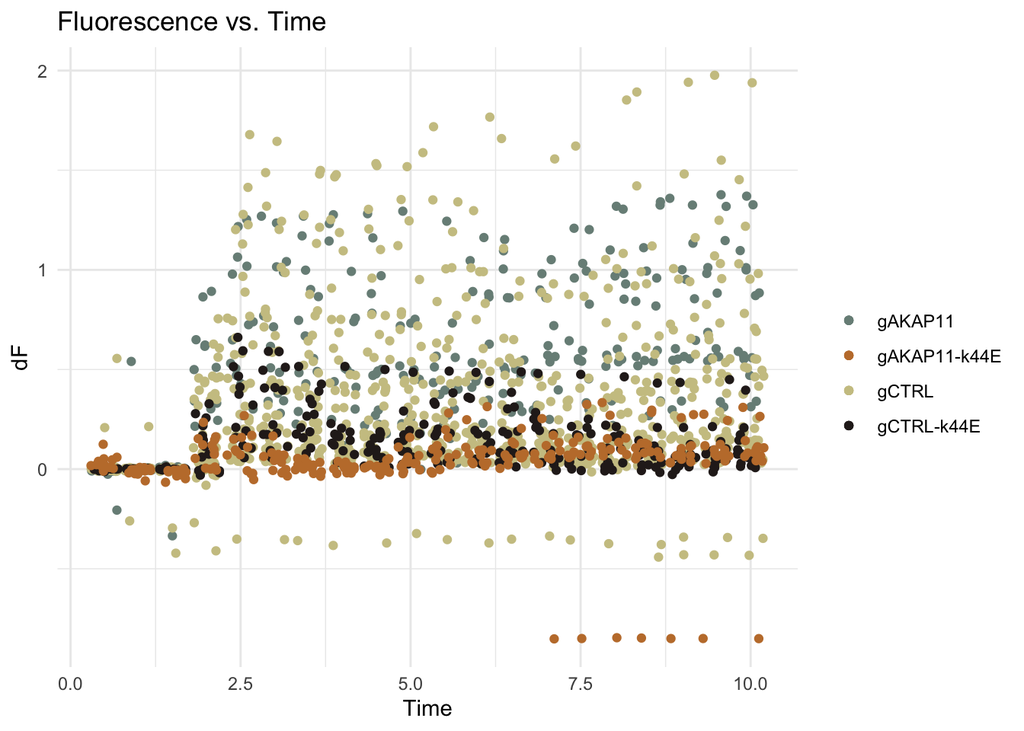

```r
# means <- PKA_df %>%
#     group_by(Time) %>%
#     summarise_each(funs(round(mean(., na.rm = TRUE),2)))
ggplot(PKA_df, aes(x = Time)) +
  geom_jitter(aes(y = gAKAP11, color = "gAKAP11")) +
  geom_jitter(aes(y = gCTRL, color = "gCTRL")) +
  geom_jitter(aes(y = gCTRL_k44E, color = "gCTRL-k44E")) +
  geom_jitter(aes(y = gAKAP11_k44E, color = "gAKAP11-k44E")) +
  scale_color_manual(values = wes_palette("Moonrise2", n=4)) +
   # c("gCTRL" = "red", "gCTRL-k44E" = "orange", "gAKAP11" = "cyan", "gAKAP11-k44E" = "purple")) +
  labs(title = "Fluorescence vs. Time",
       color = "",
       y = "dF") +
  theme_minimal()
```

## Grouping by time and summarizing means

I decided to get the mean for my different conditions at different times. In my dataset, fluorescence is calculated for each condition at every half a second for 10 seconds. Because my replicates were all spread out in the dataset, it took me many errors to figure out how to group everything by Time and then use the summarise function to get the mean for different conditions via pipe. I also had to put the na.rm (remove na values) line to disregard my empty cells.

This gave me a single line mapping the changing average fluorescence of the sensor in the cells. The initial timepoints are close to zero and, in all conditions, shoot up when I stimulated the cells.

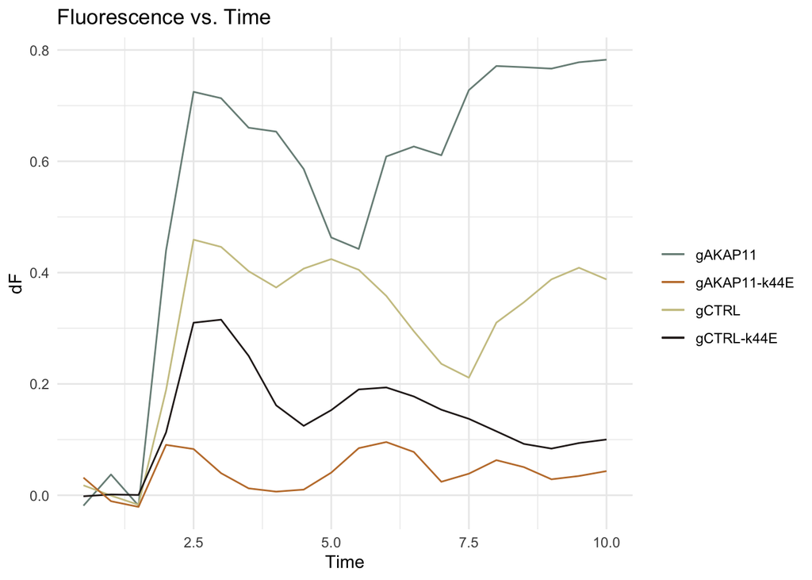

```r
PKA_df %>%
  group_by(Time) %>%
  summarise(gCTRL = mean(gCTRL, na.rm = TRUE), gCTRL_k44E = mean(gCTRL_k44E, na.rm = TRUE), gAKAP11 = mean(gAKAP11, na.rm = TRUE), gAKAP11_k44E = mean(gAKAP11_k44E, na.rm = TRUE)) %>%
  ggplot(aes(x = Time)) +
  geom_line(aes(y = gAKAP11, color = "gAKAP11")) +
  geom_line(aes(y = gCTRL, color = "gCTRL")) +
  geom_line(aes(y = gCTRL_k44E, color = "gCTRL-k44E")) +
  geom_line(aes(y = gAKAP11_k44E, color = "gAKAP11-k44E")) +
  scale_color_manual(values = wes_palette("Moonrise2", n=4)) +
  labs(title = "Fluorescence vs. Time",
       color = "",
       fill = "",
       y = "dF") +
  theme_minimal()
```

## Filling area under the curve

Another thing I wanted to do was fill in the area under the curve to highlight the difference in fluorescence among the conditions. There might have been a simpler way to do it, but I just added a geom_area function and filled it in with the appropriate color code under fill. Order matters here, so I arranged the conditions as they appeared by line height.

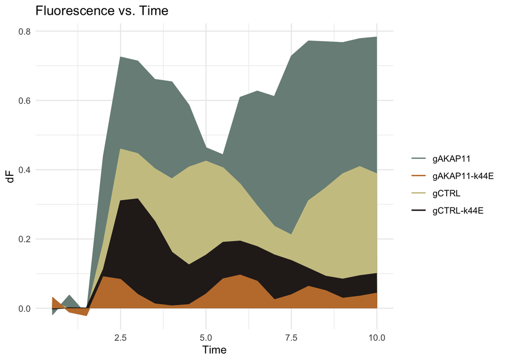

```r
PKA_df %>%
  group_by(Time) %>%
  summarise(gCTRL = mean(gCTRL, na.rm = TRUE), gCTRL_k44E = mean(gCTRL_k44E, na.rm = TRUE), gAKAP11 = mean(gAKAP11, na.rm = TRUE), gAKAP11_k44E = mean(gAKAP11_k44E, na.rm = TRUE)) %>%
  ggplot(aes(x = Time, y = gCTRL, gCTRL_k44E, gAKAP11, gAKAP11_k44E)) +
  geom_line(aes(y = gAKAP11, color = "gAKAP11")) +
  geom_area(aes(y = gAKAP11), fill = "#798E87") +
  geom_line(aes(y = gCTRL, color = "gCTRL")) +
  geom_area(aes(y = gCTRL), fill = "#CCC591") +
  geom_line(aes(y = gCTRL_k44E, color = "gCTRL-k44E")) +
  geom_area(aes(y = gCTRL_k44E), fill = "#29211F") +
  geom_line(aes(y = gAKAP11_k44E, color = "gAKAP11-k44E")) +
  geom_area(aes(y = gAKAP11_k44E), fill = "#C27D38") +
  scale_color_manual(values = wes_palette("Moonrise2", n=4)) +
  labs(title = "Fluorescence vs. Time",
       color = "",
       fill = "",
       y = "dF") +
  theme_minimal()
```

## Conclusions

As expected, there a lower degree of fluorescence produced by the cytosolic PKA sensor when the cells are infected with a dynamin inhibitor (prevents internalization of receptors). My gAKAP11 cells, which lack a scaffolding proteinappears to have a higher degree of PKA signaling. This may be because the regulators affecting that signaling are more free to move around the cell and result in more PKA stimulating the sensor, but that doesn’t quite explain why the gAKAP11 cells with the dynamin inhibitor are lower than the control cells with the dynamin inhibitor.

## Prioritized follow-up studies

This experiment definitely has to be repeated, and with a plasma membrane sensor added to the mix, as dynamin inhibition only prevents receptor internalization into the cell. A western blot testing PKA levels for each condition in conjunction with this would also be cool to see.

## Acknowledgements

Thank you to Matt, Akshay, and Tomo (I hope I spelled your name right) for teaching me the basics of R! And also to Kathy for helping me collect this microscope data and guiding me through this project.